# Lecture 18: Multinomial Classification with Keras and ELS:2002

## Overview

In the previous lectures we built intuition for neural networks, worked through backpropagation by hand, and explored regularization strategies. Today we put all of that together in a real applied problem: predicting college major field of study from the Education Longitudinal Study of 2002 (ELS:2002), using a multilayer perceptron (MLP) fit via **Keras** inside the tidymodels framework.

Along the way we will pay particular attention to the features Keras provides that you either cannot do at all in PyTorch, or that require substantially more boilerplate. The headline items:

1. **Callbacks** — early stopping, learning rate scheduling, and custom logging are first-class objects in Keras, wired directly into `model.fit()`.
2. **`validation_split`** — Keras can carve out a held-out slice of training data automatically, with no extra code from you.
3. **Opinionated defaults** — Keras ships with sensible defaults for optimizers, loss functions, and initializers. For a multinomial problem this means you get `softmax` output and `categorical_crossentropy` for free.
4. **Training history** — Keras returns a `History` object after every fit, giving you epoch-level loss and metric curves without writing a custom loop.

PyTorch is more flexible and often faster, but that flexibility comes at the cost of writing more infrastructure. Keras trades some of that ceiling for a much lower floor. For applied social science and education research — where the bottleneck is usually data and domain knowledge, not model architecture — that tradeoff is often worth it.

## Setup and Libraries

```r
library(tidyverse)
library(haven)
library(here)
library(janitor)
library(tidymodels)
library(keras)      # Keras R interface (wraps TensorFlow)
library(vip)        # Permutation-based variable importance
library(kableExtra)
```

```r
# Shared plot theme used throughout
theme_els <- function() {
  theme_minimal(base_size = 11) +
    theme(
      plot.title    = element_text(face = "bold", size = 12),
      plot.subtitle = element_text(color = "grey40", size = 10),
      axis.title    = element_text(size = 10),
      legend.position = "bottom",
      panel.grid.minor = element_blank()
    )
}
```

## The Research Problem

ELS:2002 followed a nationally representative cohort of 10th graders through high school and into postsecondary education. Our analytic sample consists of students who:

- Ever enrolled in postsecondary education (`f2evratt == 1`), and
- Completed a bachelor’s degree with an observed CIP-2 major code (`f3tzbch1cip2` is not missing).

Race and gender are withheld from the predictor set entirely; they are reserved for a post-hoc subgroup analysis.

## Data Wrangling

### Variable Inventory

The variable selection spans four ELS waves. Broadly:

- **BY (base year, 10th grade):** demographics, cognitive achievement scores, psychosocial scales, aspirations, school context.
- **F1 (12th grade):** updated expectations, highest math course, PS plans.
- **F2 (2006):** first postsecondary institution characteristics, enrollment behavior.
- **F3TZ (postsecondary transcript, early years only):** credits earned and GPA in years 1–2. *Only early-enrollment transcript variables are used* — later transcript variables would leak information about the major itself.

```r
els_vars <- c(
  "stu_id",

  # Outcome
  "f3tzbch1cip2",

  # Student background (BY)
  "bygnstat", "bystlang", "byfcomp", "bysibhom",
  "bypared", "bymothed", "byfathed", "bygpared",
  "byoccum", "byoccuf", "byincome", "byses2",
  "bygrdrpt", "byriskfc",

  # Cognitive achievement (BY)
  "bytxmstd", "bytxrstd",

  # Psychosocial scales (BY)
  "bymathse", "byenglse", "byconexp", "byinstmo",
  "byactctl", "bystprep", "byacclim",

  # Aspirations & plans (BY)
  "bystexp", "byparasp", "byocc30",

  # Behavioral engagement (BY)
  "byhmwrk", "bynsport", "byxtracu", "byworksy", "bywrkhrs",

  # School context (BY)
  "bysctrl", "byurban", "byregion",

  # F1 wave (senior year 2004)
  "f1stexp", "f1byedex", "f1mathse",
  "f1occ30", "f1psepln",
  "f1ses2",  "f1xtracu", "f1wrkhrs",
  "f1colinf", "f1himath", "f1pared",

  # F2 postsecondary context (2006)
  "f2evratt",  "f2ps1lvl", "f2ps1sec",
  "f2ps1ftp",  "f2ps1rem", "f2ps1aid",
  "f2psstrt",  "f2enrgap", "f2switch",
  "f2stexp",   "f2f1edex", "f2pseexm", "f2psepln",
  "f2psapsl",  "f2ptn3ps",

  # F3TZ transcript — early enrollment only (years 1–2; safe predictors)
  "f3tzps1sec", "f3tzps1slc",
  "f3tzhs2ps1",
  "f3tzyr1ern", "f3tzyr2ern", "f3tzyr12ern",
  "f3tzyr1gpa", "f3tzyr2gpa",
  "f3tzremtot", "f3tzremmttot", "f3tzrementot",
  "f3tznumcrswd",

  # Subgroup analysis variables — NOT model predictors
  "bysex", "byrace"
)

# Nominal variables to cast as factors before the recipe
nominal_vars <- c(
  "bygnstat", "bystlang", "byfcomp",
  "byoccum",  "byoccuf",  "byocc30",
  "bysctrl",  "byurban",  "byregion",
  "byworksy",
  "f1psepln", "f1colinf", "f1himath", "f1occ30",
  "f2ps1lvl", "f2ps1sec",
  "f2ps1ftp", "f2ps1rem", "f2ps1aid",
  "f2enrgap", "f2switch", "f2pseexm",
  "f2ptn3ps",
  "f3tzps1sec", "f3tzps1slc"
)
```

### Loading and Cleaning

NCES uses negative codes (–1 through –9) to encode various forms of non-response and skip patterns. We recode all of these to `NA` after loading.

```r
load_els <- function(path) {
  read_dta(path) %>%
    clean_names() %>%
    select(any_of(els_vars)) %>%
    mutate(across(everything(), haven::zap_labels)) %>%
    mutate(across(where(is.numeric), ~ replace(.x, .x %in% -9:-1, NA)))
}

load_cip_labels <- function(path) {
  read_csv(path, show_col_types = FALSE)
}

wrangle_els <- function(els_raw, cip_labels) {
  cip_collapse <- cip_labels %>%
    select(cip2_code, cip2_collapsed_code, cip2_collapsed_label) %>%
    distinct()

  els_raw %>%
    mutate(across(any_of(nominal_vars), as.factor)) %>%
    left_join(cip_collapse, by = join_by(f3tzbch1cip2 == cip2_code)) %>%
    mutate(
      cip2 = factor(
        cip2_collapsed_code,
        levels = sort(unique(cip_collapse$cip2_collapsed_code))
      )
    )
}

make_analytic_sample <- function(els_clean) {
  els_clean %>%
    filter(f2evratt == 1, !is.na(cip2))
}
```

```r
els_raw       <- load_els(here("scripts","els_02_12_byf3pststu_v1_0.dta"))
cip_labels    <- load_cip_labels(here("scripts","cip2_labels.csv"))
els_clean     <- wrangle_els(els_raw, cip_labels)
analytic_sample <- make_analytic_sample(els_clean)

saveRDS(analytic_sample, here("analytic_sample.rds"))
```

```r
analytic_sample <- readRDS(here::here("analytic_sample.rds"))
cip_labels      <- read_csv(here("scripts","cip2_labels.csv"),
                                   show_col_types = FALSE)
```

### Outcome Distribution

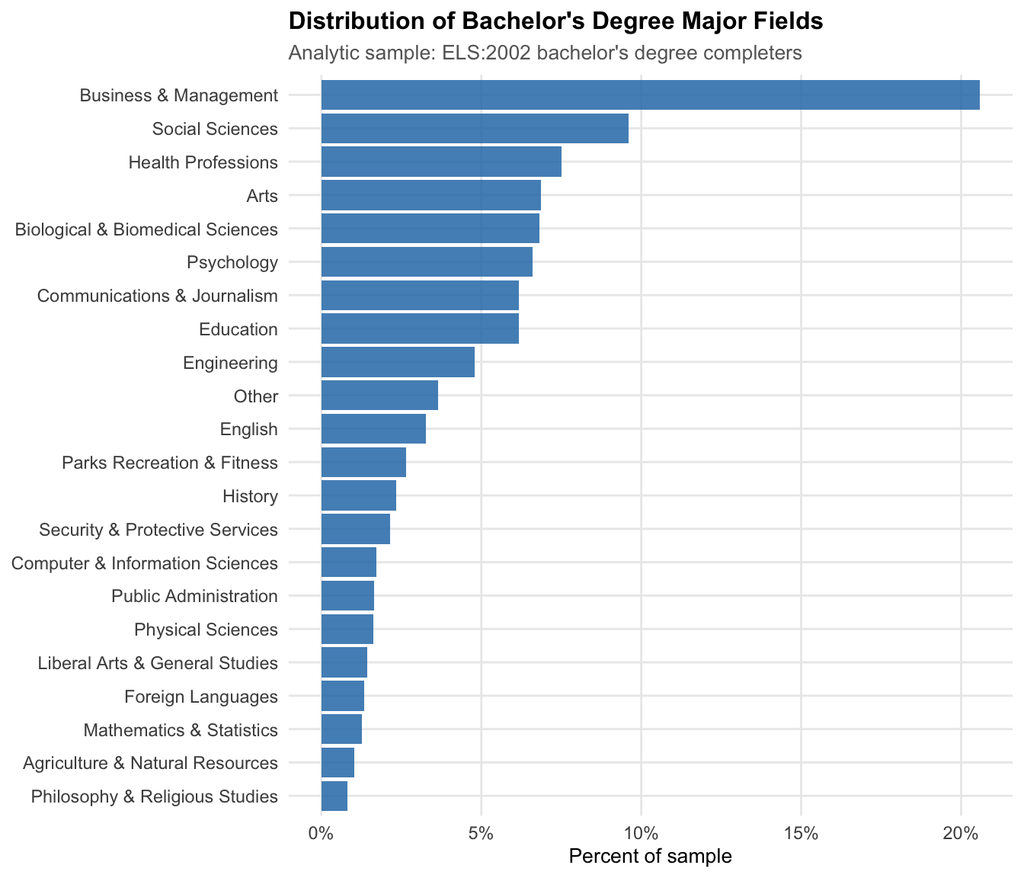

```r
label_lookup <- cip_labels %>%
  select(cip2_collapsed_code, cip2_collapsed_label) %>%
  distinct() %>%
  mutate(cip2_collapsed_code = as.factor(cip2_collapsed_code))

analytic_sample %>%
  count(cip2) %>%
  mutate(pct = n / sum(n)) %>%
  left_join(label_lookup, by = join_by(cip2 == cip2_collapsed_code)) %>%
  mutate(cip2_collapsed_label = fct_reorder(cip2_collapsed_label, pct)) %>%
  ggplot(aes(x = pct, y = cip2_collapsed_label)) +
  geom_col(fill = "#2C7BB6", alpha = 0.85) +
  scale_x_continuous(labels = scales::percent_format(accuracy = 1)) +
  labs(
    title    = "Distribution of Bachelor's Degree Major Fields",
    subtitle = "Analytic sample: ELS:2002 bachelor's degree completers",
    x        = "Percent of sample",
    y        = NULL
  ) +
  theme_els()
```

The outcome is imbalanced — Business and Social Sciences are far more common than Computer Science or Engineering. This has direct implications for how we choose metrics (more on that in the evaluation section) and how Keras handles the output layer.

### Missingness

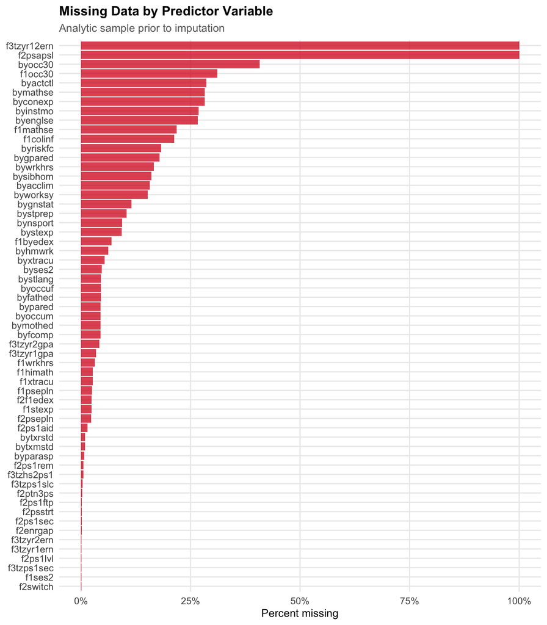

```r
analytic_sample %>%
  select(-stu_id, -bysex, -byrace, -f3tzbch1cip2,
         -cip2_collapsed_code, -cip2_collapsed_label) %>%
  summarise(across(everything(),
                   list(n_missing   = ~ sum(is.na(.x)),
                        pct_missing = ~ mean(is.na(.x))))) %>%
  pivot_longer(everything(),
               names_to    = c("variable", ".value"),
               names_pattern = "^(.+)_(n_missing|pct_missing)$") %>%
  filter(pct_missing > 0) %>%
  mutate(variable = fct_reorder(variable, pct_missing)) %>%
  ggplot(aes(x = pct_missing, y = variable)) +
  geom_col(fill = "#D7191C", alpha = 0.75) +
  scale_x_continuous(labels = scales::percent_format(accuracy = 1)) +
  labs(
    title    = "Missing Data by Predictor Variable",
    subtitle = "Analytic sample prior to imputation",
    x        = "Percent missing",
    y        = NULL
  ) +
  theme_els()
```

## Train/Test Split and Cross-Validation

```r
set.seed(2002)
els_split <- initial_split(analytic_sample, prop = 0.80, strata = cip2)
els_train <- training(els_split)
els_test  <- testing(els_split)
```

We use stratified splits to preserve the class distribution across training and test sets — important given the imbalance we saw above.

```r
set.seed(2002)
els_folds <- vfold_cv(els_train, v = 5, strata = cip2)
```

## Preprocessing Recipe

The recipe codifies every preprocessing step in a reproducible, leak-free way. Steps are applied in order, and all parameters (medians, standard deviations) are estimated only from the training fold — never from the test data.

```r
els_recipe <- recipe(cip2 ~ ., data = els_train) %>%

  # Non-predictor roles — included in the data but excluded from the model matrix
  update_role(stu_id,              new_role = "id") %>%
  update_role(bysex,               new_role = "subgroup") %>%
  update_role(byrace,              new_role = "subgroup") %>%
  update_role(f3tzbch1cip2,        new_role = "original_outcome") %>%
  update_role(cip2_collapsed_code,  new_role = "id") %>%
  update_role(cip2_collapsed_label, new_role = "id") %>%

  # Missingness indicators before imputation
  # The *fact* of missing transcript data carries signal about PS pathways
  step_indicate_na(f3tzyr1ern, f3tzyr2ern, f3tzyr1gpa, f3tzyr2gpa) %>%

  # Imputation
  step_impute_median(all_numeric_predictors()) %>%
  step_impute_mode(all_nominal_predictors()) %>%

  # Dummy encoding
  # step_novel() guards against factor levels in CV/test folds not seen in training
  step_novel(all_nominal_predictors()) %>%
  # one_hot = TRUE: no reference category dropped; Keras needs dense numeric input
  step_dummy(all_nominal_predictors(), one_hot = TRUE) %>%

  # Housekeeping
  step_zv(all_predictors()) %>%
  step_normalize(all_numeric_predictors())
```

**Why `one_hot = TRUE`?** Standard dummy encoding drops one reference category per factor to avoid the dummy variable trap in linear models. Neural networks have no such constraint — no matrix inversion, no multicollinearity problem — and symmetric encoding can help the network learn representations for all levels equally. We keep all dummies.

**Why normalize?** Keras uses gradient-based optimization (Adam by default). If predictors are on wildly different scales, gradients will be dominated by large-magnitude variables, and training will be slow or unstable. Normalizing to mean 0, standard deviation 1 is not optional here — it is required.

```r
# Face validity: how many predictors after preprocessing?
prepped <- prep(els_recipe, training = els_train)
baked   <- bake(prepped, new_data = NULL)

cat("Rows in baked training data:", nrow(baked), "\n")
```

```
## Rows in baked training data: 3881
```

```r
cat("Columns (outcome + predictors):", ncol(baked), "\n")
```

```
## Columns (outcome + predictors): 223
```

```r
cat("Number of predictors:", ncol(baked) - 1, "\n")
```

```
## Number of predictors: 222
```

## Keras-Specific Features

Before we build the model spec, it’s worth pausing to understand what Keras is doing under the hood and where it differs from PyTorch.

### The Architecture

We use a two-hidden-layer MLP (the default for `parsnip`’s Keras engine). Each hidden layer uses **ReLU** activation. The output layer uses **softmax**, which converts the raw logit scores into a proper probability distribution over all major categories. This is automatic in Keras — you do not specify the output layer manually when using `parsnip`.

```
Input (p predictors)
    ↓
Hidden Layer 1: hidden_units nodes, ReLU + Dropout
    ↓
Hidden Layer 2: hidden_units nodes, ReLU + Dropout
    ↓
Output: K nodes (one per major category), Softmax
```

### Feature 1: Callbacks

Keras **callbacks** are objects that can inspect and modify training at the end of each epoch. PyTorch has no built-in equivalent — you write a training loop and add your own logic. Keras callbacks are first-class objects that plug directly into `model.fit()`.

The most important for us is **early stopping**: we specify a maximum number of epochs, but allow training to halt early if the validation loss stops improving.

```r
# This is what Keras runs internally when you pass callbacks via set_engine()
callback_early_stopping(
  monitor              = "val_loss",   # watch held-out validation loss
  patience             = 15,           # tolerate 15 epochs without improvement
  restore_best_weights = TRUE          # rewind to the best epoch's weights
)
```

`restore_best_weights = TRUE` is subtle but important: without it, you get the weights from the *last* epoch, which may be worse than an earlier checkpoint. Keras handles this bookkeeping for you. In PyTorch you would save a checkpoint manually at each epoch and reload it at the end.

Other useful callbacks you can pass the same way:

```r
# Reduce learning rate when improvement plateaus (learning rate scheduling)
callback_reduce_lr_on_plateau(
  monitor  = "val_loss",
  factor   = 0.5,          # multiply LR by 0.5 when plateau detected
  patience = 5
)

# Write TensorBoard logs for interactive visualization
callback_tensorboard(log_dir = "logs/run_01")

# Save model weights after each epoch (model checkpointing)
callback_model_checkpoint(
  filepath          = "checkpoints/weights_{epoch}.keras",
  save_best_only    = TRUE
)
```

You can combine multiple callbacks in a list — Keras runs all of them in sequence at the end of each epoch. All of this is in Keras’s standard library. PyTorch users typically reach for separate packages (`lightning`, `ignite`) or write this infrastructure themselves.

### Feature 2: `validation_split`

When you pass `validation_split = 0.2` to `set_engine("keras", ...)`, Keras automatically holds out the last 20% of the training data (by row order) as a validation set. This validation set is used by callbacks to monitor performance — it is not the test set.

In PyTorch you would split the `DataLoader` manually, or use a `SubsetRandomSampler`. Keras does it in one argument.

> **Important distinction:** The 20% `validation_split` inside Keras is *not* the same as the tidymodels CV folds. The CV folds evaluate which hyperparameter combination is best. The internal `validation_split` gives the early stopping callback its signal within each individual training run. They are nested: for each fold/grid-point combination, Keras trains on 80% of that fold’s training data and monitors loss on the other 20%.

### Feature 3: Training History

Every Keras `model.fit()` call returns a `History` object with epoch-by-epoch loss and metric values for both training and validation. Through the parsnip interface this is less directly accessible, but when you use Keras directly you get it for free:

```r
# Direct Keras API (outside of tidymodels)
history <- model %>% fit(
  x_train, y_train,
  epochs           = 200,
  validation_split = 0.2,
  callbacks        = list(callback_early_stopping(patience = 15))
)

# Plot training vs. validation loss over epochs — built in
plot(history)
```

In PyTorch you append to a list inside your training loop. Keras returns it automatically.

## Model Specification

```r
keras_spec <- mlp(
  hidden_units = tune(),
  epochs       = tune(),
  penalty      = 0,       # fixed — cannot specify alongside dropout in Keras engine
  dropout      = tune()
  # learn_rate is not exposed by the Keras parsnip engine
  # Adam optimizer uses its default (0.001)
) %>%
  set_engine(
    "keras",
    validation_split = 0.2,
    callbacks = list(
      keras::callback_early_stopping(
        monitor              = "val_loss",
        patience             = 15,
        restore_best_weights = TRUE
      )
    )
  ) %>%
  set_mode("classification")
```

**The `penalty`/`dropout` constraint.** The Keras parsnip engine does not allow `penalty` (L2 regularization) and `dropout` to be tuned simultaneously in a single `mlp()` call. This is an engine-level limitation, not a Keras limitation. If you need both, the cleanest solution is to run two separate tuning workflows (dropout-only and L2-only) and compare their best configurations. We focus on dropout here.

**The `learn_rate` situation.** The Keras parsnip engine does not expose `learn_rate` as a tunable parameter through `mlp()`. Adam’s default (0.001) is used. If you need to tune the learning rate, you can pass a custom optimizer through engine arguments:

```r
# Advanced: custom learning rate via engine argument
mlp(...) %>%
  set_engine(
    "keras",
    optimizer = keras::optimizer_adam(learning_rate = 0.0005)
  )
```

## Workflow

```r
els_workflow <- workflow() %>%
  add_recipe(els_recipe) %>%
  add_model(keras_spec)
```

## Hyperparameter Tuning

### Tuning Grid

We use a **space-filling Latin hypercube** design. Rather than an exhaustive grid (which scales as $k^p$ where $k$ is levels and $p$ is parameters), a space-filling design spreads points evenly across the hyperparameter space, giving much better coverage with far fewer evaluations.

```r
set.seed(2002)
tuning_grid <- grid_space_filling(
  hidden_units(range = c(32L, 256L)),
  epochs(range       = c(50L, 300L)),
  dropout(range      = c(0, 0.5)),
  size = 20
)

tuning_grid
```

```
## # A tibble: 20 × 3
##    hidden_units epochs dropout
##           <int>  <int>   <dbl>
##  1           32    207  0.184
##  2           43    102  0.289
##  3           55    247  0.368
##  4           67    115  0.0789
##  5           79    168  0.474
##  6           90    221  0.0263
##  7          102    300  0.211
##  8          114     76  0.421
##  9          126     50  0.158
## 10          138    181  0.263
## 11          149    273  0.447
## 12          161    128  0
## 13          173    260  0.0526
## 14          185    155  0.5
## 15          197     63  0.342
## 16          208    286  0.237
## 17          220     89  0.132
## 18          232    234  0.395
## 19          244    194  0.105
## 20          256    142  0.316
```

### Running the Tuning

```r
# Keras manages its own internal threading via TensorFlow.
# Running multiple Keras sessions in parallel R workers causes memory conflicts
# and is typically slower on CPU. We keep allow_par = FALSE.
tuning_results <- tune_grid(
  els_workflow,
  resamples = els_folds,
  grid      = tuning_grid,
  metrics   = metric_set(roc_auc, accuracy, mn_log_loss),
  control   = control_grid(
    save_pred = TRUE,
    verbose   = TRUE,
    allow_par = FALSE
  )
)

saveRDS(tuning_results, here("scripts","tuning_results.rds"))
```

```r
tuning_results <- readRDS(here("scripts","tuning_results.rds"))
```

### Examining Tuning Results

```r
# Summary across all grid points
collect_metrics(tuning_results, summarize = TRUE) %>%
  filter(.metric == "roc_auc") %>%
  arrange(desc(mean)) %>%
  select(hidden_units, epochs, dropout, mean, std_err) %>%
  head(5) %>%
  kable(digits = 3, caption = "Top 5 hyperparameter combinations by ROC AUC") %>%
  kable_styling(bootstrap_options = c("striped", "condensed"))
```

Top 5 hyperparameter combinations by ROC AUC

| hidden_units | epochs | dropout | mean | std_err |
| --- | --- | --- | --- | --- |
| 161 | 128 | 0.000 | 0.568 | 0.006 |
| 173 | 260 | 0.053 | 0.543 | 0.008 |
| 67 | 115 | 0.079 | 0.534 | 0.009 |
| 256 | 142 | 0.316 | 0.532 | 0.007 |
| 244 | 194 | 0.105 | 0.528 | 0.005 |

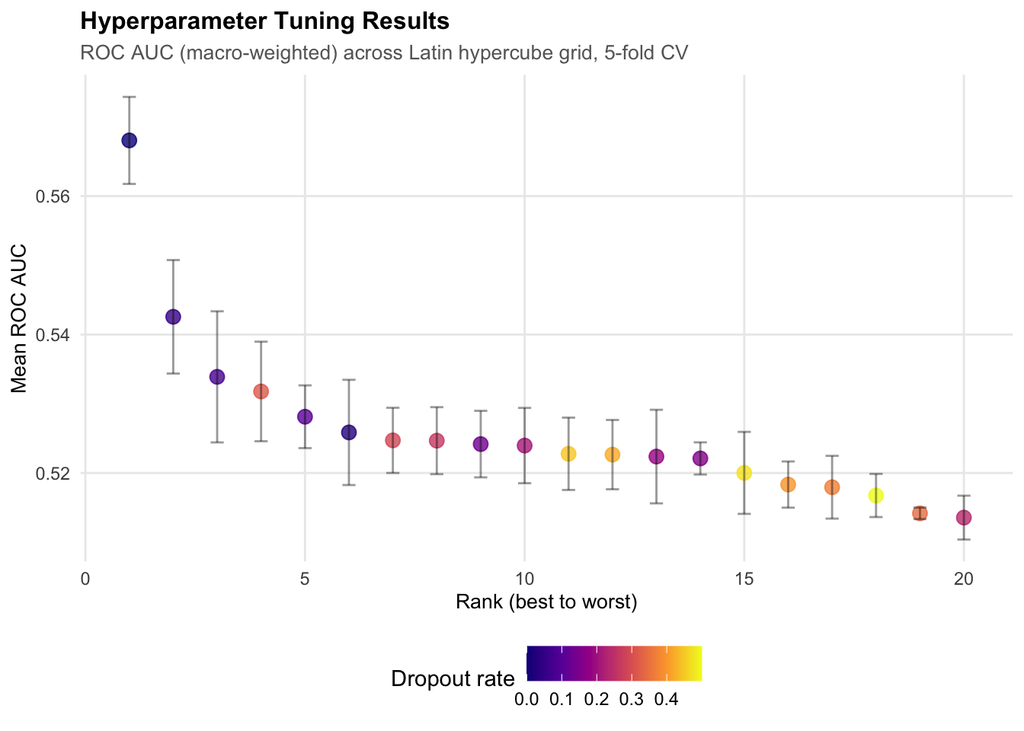

```r
# Ranked performance plot with dropout color-coded
collect_metrics(tuning_results) %>%
  filter(.metric == "roc_auc") %>%
  arrange(desc(mean)) %>%
  mutate(rank = row_number()) %>%
  ggplot(aes(x = rank, y = mean)) +
  geom_point(aes(color = dropout), size = 3, alpha = 0.8) +
  geom_errorbar(aes(ymin = mean - std_err, ymax = mean + std_err),
                width = 0.3, alpha = 0.4) +
  scale_color_viridis_c(option = "plasma") +
  labs(
    title    = "Hyperparameter Tuning Results",
    subtitle = "ROC AUC (macro-weighted) across Latin hypercube grid, 5-fold CV",
    x        = "Rank (best to worst)",
    y        = "Mean ROC AUC",
    color    = "Dropout rate"
  ) +
  theme_els()
```

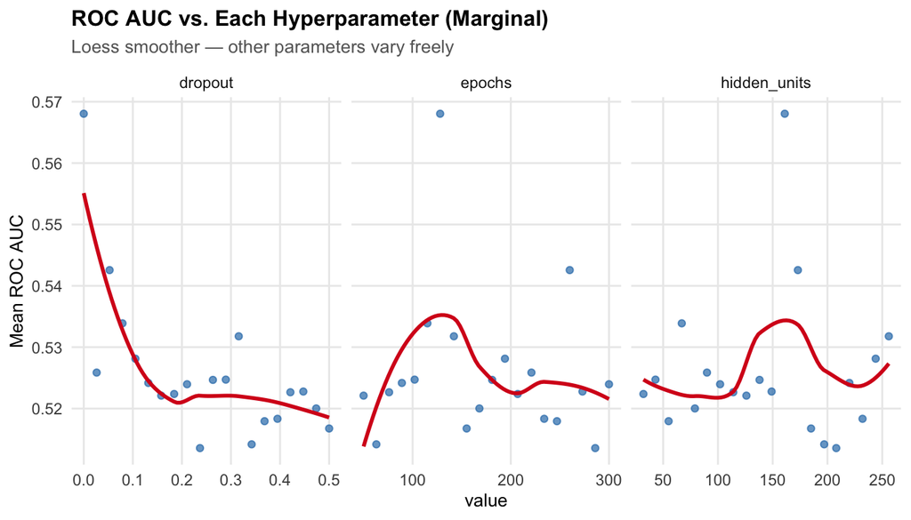

```r
# How does each parameter relate to performance?
collect_metrics(tuning_results) %>%
  filter(.metric == "roc_auc") %>%
  select(mean, hidden_units, epochs, dropout) %>%
  pivot_longer(c(hidden_units, epochs, dropout),
               names_to = "parameter", values_to = "value") %>%
  ggplot(aes(x = value, y = mean)) +
  geom_point(alpha = 0.7, color = "#2C7BB6") +
  geom_smooth(method = "loess", se = FALSE, color = "#D7191C") +
  facet_wrap(~ parameter, scales = "free_x") +
  labs(
    title = "ROC AUC vs. Each Hyperparameter (Marginal)",
    subtitle = "Loess smoother — other parameters vary freely",
    y = "Mean ROC AUC"
  ) +
  theme_els()
```

```r
# Face validity: compare best model to null classifier
null_acc <- analytic_sample %>%
  count(cip2) %>%
  mutate(pct = n / sum(n)) %>%
  slice_max(pct, n = 1) %>%
  pull(pct)

best_roc <- show_best(tuning_results, metric = "roc_auc", n = 1) %>%
  pull(mean)

cat("Null classifier accuracy (always predict most common class):",
    round(null_acc, 3), "\n")
```

```
## Null classifier accuracy (always predict most common class): 0.206
```

```r
cat("Best model ROC AUC (macro-weighted):                         ",
    round(best_roc, 3), "\n")
```

```
## Best model ROC AUC (macro-weighted):                          0.568
```

```r
# Is there meaningful variation across grid points?
collect_metrics(tuning_results) %>%
  filter(.metric == "roc_auc") %>%
  summarise(
    min   = min(mean),
    max   = max(mean),
    range = max(mean) - min(mean),
    sd    = sd(mean)
  ) %>%
  kable(digits = 3, caption = "Performance range across tuning grid") %>%
  kable_styling(bootstrap_options = "condensed")
```

Performance range across tuning grid

| min | max | range | sd |
| --- | --- | --- | --- |
| 0.514 | 0.568 | 0.054 | 0.012 |

## Selecting Best Parameters and Final Fit

```r
best_params <- select_best(tuning_results, metric = "roc_auc")
best_params
```

```
## # A tibble: 1 × 4
##   hidden_units dropout epochs .config
##          <int>   <dbl>  <int> <chr>
## 1          161       0    128 pre0_mod12_post0
```

```r
# Finalize the workflow with the best hyperparameter values
final_workflow <- finalize_workflow(els_workflow, best_params)
```

`last_fit()` fits the finalized model on the **full training set** and evaluates it on the held-out **test set**. This is the only time the test set is touched.

```r
set.seed(2002)
final_fit <- last_fit(
  final_workflow,
  split   = els_split,
  metrics = metric_set(roc_auc, accuracy, mn_log_loss)
)
```

[output not shown]

[output cut: 30 more lines]

[output not shown]

```r
# Save fit for prediction later-- some weirdness with keras
fitted_wf <- extract_workflow(final_fit)


#saveRDS(final_fit, here("scripts","final_fit.rds"))
```

```r
#final_fit <- readRDS(here("scripts","final_fit.rds"))
```